# HR DATASET ANALYSIS OF EMPLOYEE ATTRITION

```python
import pandas as pd
import numpy as np
import matplotlib.pyplot as plt
import seaborn as sns
import plotly.express as px
pd.pandas.set_option("display.max_columns", None)
import warnings

warnings.filterwarnings("ignore")

%matplotlib inline
```

```python
df=pd.read_csv(r"C:\Users\HP\OneDrive\Desktop\Used car project\HR_DATASET.csv")
```

```python
df.head()
```

|  | Age | Attrition | BusinessTravel | DailyRate | Department | DistanceFromHome | Education | EducationField | EmployeeCount | EmployeeNumber | EnvironmentSatisfaction | Gender | HourlyRate | JobInvolvement | JobLevel | JobRole | JobSatisfaction | MaritalStatus | MonthlyIncome | MonthlyRate | NumCompaniesWorked | Over18 | OverTime | PercentSalaryHike | PerformanceRating | RelationshipSatisfaction | StandardHours | StockOptionLevel | TotalWorkingYears | … |
| --- | --- | --- | --- | --- | --- | --- | --- | --- | --- | --- | --- | --- | --- | --- | --- | --- | --- | --- | --- | --- | --- | --- | --- | --- | --- | --- | --- | --- | --- | --- |
| 0 | 41 | Yes | Travel_Rarely | 1102 | Sales | 1 | 2 | Life Sciences | 1 | 1 | 2 | Female | 94 | 3 | 2 | Sales Executive | 4 | Single | 5993 | 19479 | 8 | Y | Yes | 11 | 3 | 1 | 80 | 0 | 8 | … |
| 1 | 49 | No | Travel_Frequently | 279 | Research & Development | 8 | 1 | Life Sciences | 1 | 2 | 3 | Male | 61 | 2 | 2 | Research Scientist | 2 | Married | 5130 | 24907 | 1 | Y | No | 23 | 4 | 4 | 80 | 1 | 10 | … |
| 2 | 37 | Yes | Travel_Rarely | 1373 | Research & Development | 2 | 2 | Other | 1 | 4 | 4 | Male | 92 | 2 | 1 | Laboratory Technician | 3 | Single | 2090 | 2396 | 6 | Y | Yes | 15 | 3 | 2 | 80 | 0 | 7 | … |
| 3 | 33 | No | Travel_Frequently | 1392 | Research & Development | 3 | 4 | Life Sciences | 1 | 5 | 4 | Female | 56 | 3 | 1 | Research Scientist | 3 | Married | 2909 | 23159 | 1 | Y | Yes | 11 | 3 | 3 | 80 | 0 | 8 | … |
| 4 | 27 | No | Travel_Rarely | 591 | Research & Development | 2 | 1 | Medical | 1 | 7 | 1 | Male | 40 | 3 | 1 | Laboratory Technician | 2 | Married | 3468 | 16632 | 9 | Y | No | 12 | 3 | 4 | 80 | 1 | 6 | … |

```python
df.shape
```

```
(917, 35)
```

```python
df.describe()
```

|  | Age | DailyRate | DistanceFromHome | Education | EmployeeCount | EmployeeNumber | EnvironmentSatisfaction | HourlyRate | JobInvolvement | JobLevel | JobSatisfaction | MonthlyIncome | MonthlyRate | NumCompaniesWorked | PercentSalaryHike | PerformanceRating | RelationshipSatisfaction | StandardHours | StockOptionLevel | TotalWorkingYears | TrainingTimesLastYear | WorkLifeBalance | YearsAtCompany | YearsInCurrentRole | YearsSinceLastPromotion | YearsWithCurrManager |
| --- | --- | --- | --- | --- | --- | --- | --- | --- | --- | --- | --- | --- | --- | --- | --- | --- | --- | --- | --- | --- | --- | --- | --- | --- | --- | --- |
| count | 917.000000 | 917.000000 | 917.000000 | 917.000000 | 917.0 | 917.000000 | 917.000000 | 917.000000 | 917.000000 | 917.000000 | 917.000000 | 917.000000 | 917.000000 | 917.000000 | 917.000000 | 917.000000 | 917.000000 | 917.0 | 917.000000 | 917.000000 | 917.000000 | 917.000000 | 917.000000 | 917.000000 | 917.000000 | 917.000000 |
| mean | 36.938931 | 785.711014 | 9.294438 | 2.921483 | 1.0 | 1413.466739 | 2.738277 | 66.231189 | 2.721919 | 2.044711 | 2.688113 | 6452.293348 | 14428.468920 | 2.696838 | 15.214831 | 3.149400 | 2.637950 | 80.0 | 0.821156 | 11.179935 | 2.791712 | 2.760087 | 6.972737 | 4.217012 | 2.147219 | 4.062159 |
| std | 8.984981 | 401.902148 | 8.092566 | 1.020717 | 0.0 | 388.606884 | 1.103382 | 20.237536 | 0.720936 | 1.100400 | 1.110097 | 4685.137761 | 7188.332799 | 2.489217 | 3.640007 | 0.356677 | 1.078673 | 0.0 | 0.864555 | 7.802790 | 1.292917 | 0.708047 | 5.951250 | 3.588223 | 3.176250 | 3.571395 |
| min | 18.000000 | 102.000000 | 1.000000 | 1.000000 | 1.0 | 1.000000 | 1.000000 | 30.000000 | 1.000000 | 1.000000 | 1.000000 | 1051.000000 | 2097.000000 | 0.000000 | 11.000000 | 3.000000 | 1.000000 | 80.0 | 0.000000 | 0.000000 | 0.000000 | 1.000000 | 0.000000 | 0.000000 | 0.000000 | 0.000000 |
| 25% | 30.000000 | 444.000000 | 2.000000 | 2.000000 | 1.0 | 1084.000000 | 2.000000 | 49.000000 | 2.000000 | 1.000000 | 2.000000 | 2933.000000 | 8018.000000 | 1.000000 | 12.000000 | 3.000000 | 2.000000 | 80.0 | 0.000000 | 6.000000 | 2.000000 | 2.000000 | 3.000000 | 2.000000 | 0.000000 | 2.000000 |
| 50% | 36.000000 | 772.000000 | 7.000000 | 3.000000 | 1.0 | 1425.000000 | 3.000000 | 66.000000 | 3.000000 | 2.000000 | 3.000000 | 4877.000000 | 14255.000000 | 2.000000 | 14.000000 | 3.000000 | 3.000000 | 80.0 | 1.000000 | 10.000000 | 3.000000 | 3.000000 | 5.000000 | 3.000000 | 1.000000 | 3.000000 |
| 75% | 43.000000 | 1141.000000 | 14.000000 | 4.000000 | 1.0 | 1737.000000 | 4.000000 | 84.000000 | 3.000000 | 3.000000 | 4.000000 | 8103.000000 | 20763.000000 | 4.000000 | 18.000000 | 3.000000 | 4.000000 | 80.0 | 1.000000 | 15.000000 | 3.000000 | 3.000000 | 9.000000 | 7.000000 | 3.000000 | 7.000000 |
| max | 60.000000 | 1498.000000 | 29.000000 | 5.000000 | 1.0 | 2068.000000 | 4.000000 | 100.000000 | 4.000000 | 5.000000 | 4.000000 | 19973.000000 | 26997.000000 | 9.000000 | 25.000000 | 4.000000 | 4.000000 | 80.0 | 3.000000 | 40.000000 | 6.000000 | 4.000000 | 36.000000 | 17.000000 | 15.000000 | 17.000000 |

```python
df.info()
```

```
<class 'pandas.core.frame.DataFrame'>
RangeIndex: 917 entries, 0 to 916
Data columns (total 35 columns):
 #   Column                    Non-Null Count  Dtype
---  ------                    --------------  -----
 0   Age                       917 non-null    int64
 1   Attrition                 917 non-null    object
 2   BusinessTravel            917 non-null    object
 3   DailyRate                 917 non-null    int64
 4   Department                917 non-null    object
 5   DistanceFromHome          917 non-null    int64
 6   Education                 917 non-null    int64
 7   EducationField            917 non-null    object
 8   EmployeeCount             917 non-null    int64
 9   EmployeeNumber            917 non-null    int64
```

[output cut: 27 more lines]

```python
df.isnull().sum()
```

```
Age                         0
Attrition                   0
BusinessTravel              0
DailyRate                   0
Department                  0
DistanceFromHome            0
Education                   0
EducationField              0
EmployeeCount               0
EmployeeNumber              0
EnvironmentSatisfaction     0
Gender                      0
HourlyRate                  0
JobInvolvement              0
JobLevel                    0
JobRole                     0
JobSatisfaction             0
MaritalStatus               0
MonthlyIncome               0
MonthlyRate                 0
NumCompaniesWorked          0
Over18                      0
OverTime                    0
PercentSalaryHike           0
PerformanceRating           0
RelationshipSatisfaction    0
StandardHours               0
StockOptionLevel            0
TotalWorkingYears           0
TrainingTimesLastYear       0
WorkLifeBalance             0
YearsAtCompany              0
YearsInCurrentRole          0
YearsSinceLastPromotion     0
YearsWithCurrManager        0
dtype: int64
```

```python
## Exploratory data analysis
```

```python
# define numerical & categorical columns
numeric_features = [feature for feature in df.columns if df[feature].dtype != 'O']
categorical_features = [feature for feature in df.columns if df[feature].dtype == 'O']

# print columns
print('We have {} numerical features : {}'.format(len(numeric_features), numeric_features))
print('\nWe have {} categorical features : {}'.format(len(categorical_features), categorical_features))
```

```
We have 26 numerical features : ['Age', 'DailyRate', 'DistanceFromHome', 'Education', 'EmployeeCount', 'EmployeeNumber', 'EnvironmentSatisfaction', 'HourlyRate', 'JobInvolvement', 'JobLevel', 'JobSatisfaction', 'MonthlyIncome', 'MonthlyRate', 'NumCompaniesWorked', 'PercentSalaryHike', 'PerformanceRa…

We have 9 categorical features : ['Attrition', 'BusinessTravel', 'Department', 'EducationField', 'Gender', 'JobRole', 'MaritalStatus', 'Over18', 'OverTime']
```

```python
# proportion of count data on categorical columns
for col in categorical_features:
    print(df[col].value_counts(normalize=True) * 100)
    print('---------------------------')
```

```
No     83.206107
Yes    16.793893
Name: Attrition, dtype: float64
---------------------------
Travel_Rarely        70.665213
Travel_Frequently    18.756816
Non-Travel           10.577972
Name: BusinessTravel, dtype: float64
---------------------------
Research & Development    65.103599
Sales                     29.989095
Human Resources            4.907306
Name: Department, dtype: float64
---------------------------
Life Sciences       41.984733
Medical             31.079607
Marketing           10.032715
Technical Degree     8.942203
Other                5.997819
Human Resources      1.962923
Name: EducationField, dtype: float64
---------------------------
Male      59.97819
Female    40.02181
Name: Gender, dtype: float64
---------------------------
Sales Executive              22.137405
Research Scientist           19.847328
Laboratory Technician        17.666303
Manufacturing Director       10.032715
Healthcare Representative     9.051254
Manager                       6.324973
Sales Representative          5.452563
Research Director             5.234460
Human Resources               4.252999
Name: JobRole, dtype: float64
---------------------------
Married     47.546347
Single      31.297710
Divorced    21.155943
Name: MaritalStatus, dtype: float64
---------------------------
Y    100.0
Name: Over18, dtype: float64
---------------------------
No     71.537623
Yes    28.462377
Name: OverTime, dtype: float64
---------------------------
```

## Insight

- Column Over18 has no significance because all the values are Y hence it should be dropped.
- Column Attrition is highly biased to No.
- Column EducationField other categories except Life Sciences and Medical can be merged and taken as others.

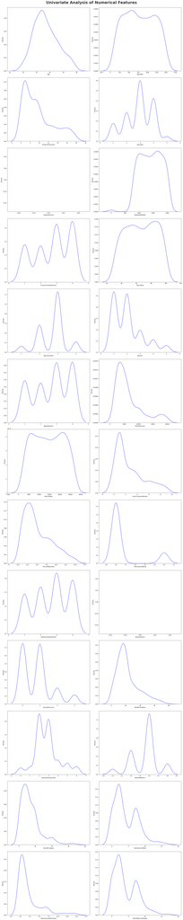

```python
plt.figure(figsize=(20, 100))
plt.suptitle('Univariate Analysis of Numerical Features', fontsize=30, fontweight='bold', alpha=0.8, y=1.)

for i in range(0, len(numeric_features)):
    plt.subplot(13, 2, i+1)
    sns.kdeplot(x=df[numeric_features[i]], color='blue')
    plt.xlabel(numeric_features[i])
    plt.tight_layout()
```

```python
# categorical columns
categorical_features.remove("Over18")
```

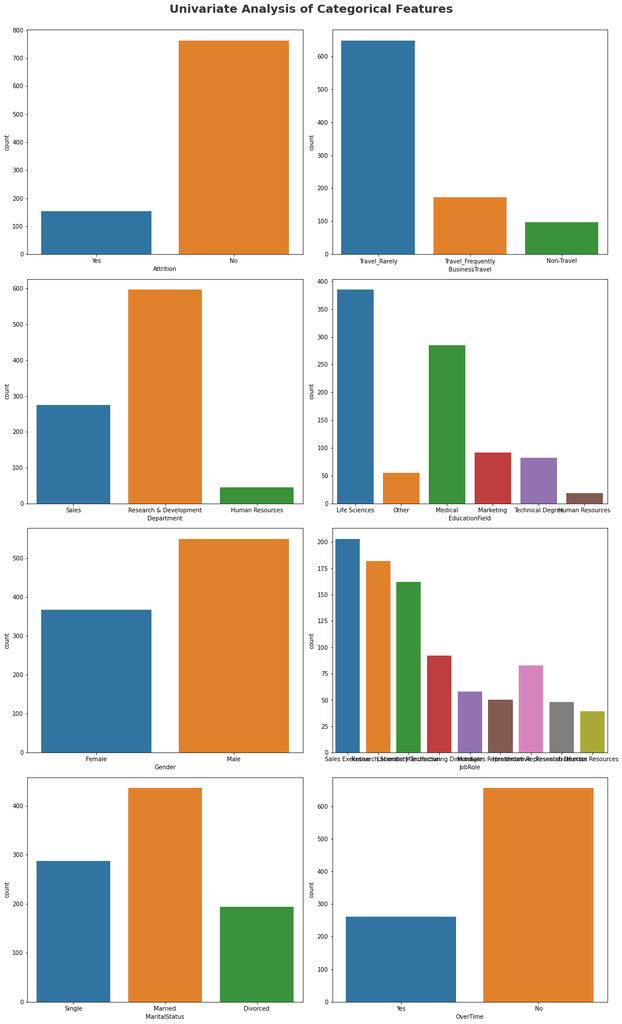

```python
plt.figure(figsize=(15, 30))
plt.suptitle('Univariate Analysis of Categorical Features', fontsize=20, fontweight='bold', alpha=0.8, y=1.)

for i in range(0, len(categorical_features)):
    plt.subplot(5, 2, i+1)
    sns.countplot(x=df[categorical_features[i]])
    plt.xlabel(categorical_features[i])
    plt.tight_layout()
```

```python
discrete_features=[feature for feature in numeric_features if len(df[feature].unique())<=25]

continuous_features=[feature for feature in numeric_features if len(df[feature].unique()) > 25]

print('We have {} discrete features : {}'.format(len(discrete_features), discrete_features))
print('\nWe have {} continuous_features : {}'.format(len(continuous_features), continuous_features))
```

```
We have 17 discrete features : ['Education', 'EmployeeCount', 'EnvironmentSatisfaction', 'JobInvolvement', 'JobLevel', 'JobSatisfaction', 'NumCompaniesWorked', 'PercentSalaryHike', 'PerformanceRating', 'RelationshipSatisfaction', 'StandardHours', 'StockOptionLevel', 'TrainingTimesLastYear', 'WorkLif…

We have 9 continuous_features : ['Age', 'DailyRate', 'DistanceFromHome', 'EmployeeNumber', 'HourlyRate', 'MonthlyIncome', 'MonthlyRate', 'TotalWorkingYears', 'YearsAtCompany']
```

```python
### Check Multicollinearity for Categorical features
```

```python
from scipy.stats import chi2_contingency
chi2_test = []
for feature in categorical_features:
    if chi2_contingency(pd.crosstab(df['Attrition'], df[feature]))[1] < 0.05:
        chi2_test.append('Reject Null Hypothesis')
    else:
        chi2_test.append('Fail to Reject Null Hypothesis')
result = pd.DataFrame(data=[categorical_features, chi2_test]).T
result.columns = ['Column', 'Hypothesis Result']
result
```

|  | Column | Hypothesis Result |
| --- | --- | --- |
| 0 | Attrition | Reject Null Hypothesis |
| 1 | BusinessTravel | Reject Null Hypothesis |
| 2 | Department | Reject Null Hypothesis |
| 3 | EducationField | Fail to Reject Null Hypothesis |
| 4 | Gender | Fail to Reject Null Hypothesis |
| 5 | JobRole | Reject Null Hypothesis |
| 6 | MaritalStatus | Reject Null Hypothesis |
| 7 | OverTime | Reject Null Hypothesis |

```python
### Check Multicollinearity for Numerical features
```

```python
from scipy.stats import ttest_ind
t_test = []
for feature in numeric_features:
    attrition_yes = df[df['Attrition'] == 'Yes'][feature]
    attrition_no = df[df['Attrition'] == 'No'][feature]
    t_statistic, p_value = ttest_ind(attrition_yes, attrition_no)
    if p_value < 0.05:
        t_test.append('Reject Null Hypothesis')
    else:
        t_test.append('Fail to Reject Null Hypothesis')

result = pd.DataFrame(data=[numeric_features, t_test]).T
result.columns = ['Column', 'Hypothesis Result']
result
```

|  | Column | Hypothesis Result |
| --- | --- | --- |
| 0 | Age | Reject Null Hypothesis |
| 1 | DailyRate | Fail to Reject Null Hypothesis |
| 2 | DistanceFromHome | Reject Null Hypothesis |
| 3 | Education | Fail to Reject Null Hypothesis |
| 4 | EmployeeCount | Fail to Reject Null Hypothesis |
| 5 | EmployeeNumber | Reject Null Hypothesis |
| 6 | EnvironmentSatisfaction | Reject Null Hypothesis |
| 7 | HourlyRate | Fail to Reject Null Hypothesis |
| 8 | JobInvolvement | Reject Null Hypothesis |
| 9 | JobLevel | Reject Null Hypothesis |
| 10 | JobSatisfaction | Reject Null Hypothesis |
| 11 | MonthlyIncome | Reject Null Hypothesis |
| 12 | MonthlyRate | Fail to Reject Null Hypothesis |
| 13 | NumCompaniesWorked | Fail to Reject Null Hypothesis |
| 14 | PercentSalaryHike | Fail to Reject Null Hypothesis |
| 15 | PerformanceRating | Fail to Reject Null Hypothesis |
| 16 | RelationshipSatisfaction | Fail to Reject Null Hypothesis |
| 17 | StandardHours | Fail to Reject Null Hypothesis |
| 18 | StockOptionLevel | Reject Null Hypothesis |
| 19 | TotalWorkingYears | Reject Null Hypothesis |
| 20 | TrainingTimesLastYear | Reject Null Hypothesis |
| 21 | WorkLifeBalance | Reject Null Hypothesis |
| 22 | YearsAtCompany | Reject Null Hypothesis |
| 23 | YearsInCurrentRole | Reject Null Hypothesis |
| 24 | YearsSinceLastPromotion | Fail to Reject Null Hypothesis |
| 25 | YearsWithCurrManager | Reject Null Hypothesis |

```python
# Checking null values
```

```python
df.isnull().sum()
```

```
Age                         0
Attrition                   0
BusinessTravel              0
DailyRate                   0
Department                  0
DistanceFromHome            0
Education                   0
EducationField              0
EmployeeCount               0
EmployeeNumber              0
EnvironmentSatisfaction     0
Gender                      0
HourlyRate                  0
JobInvolvement              0
JobLevel                    0
JobRole                     0
JobSatisfaction             0
MaritalStatus               0
MonthlyIncome               0
MonthlyRate                 0
NumCompaniesWorked          0
Over18                      0
OverTime                    0
PercentSalaryHike           0
PerformanceRating           0
RelationshipSatisfaction    0
StandardHours               0
StockOptionLevel            0
TotalWorkingYears           0
TrainingTimesLastYear       0
WorkLifeBalance             0
YearsAtCompany              0
YearsInCurrentRole          0
YearsSinceLastPromotion     0
YearsWithCurrManager        0
dtype: int64
```

```python
# Checking duplicated values
```

```python
df.duplicated().sum()
```

```
0
```

```python
continues_features=[feature for feature in numeric_features if len(df[feature].unique())>=10]
print('Num of continues features :',continues_features)
```

```
Num of continues features : ['Age', 'DailyRate', 'DistanceFromHome', 'EmployeeNumber', 'HourlyRate', 'MonthlyIncome', 'MonthlyRate', 'NumCompaniesWorked', 'PercentSalaryHike', 'TotalWorkingYears', 'YearsAtCompany', 'YearsInCurrentRole', 'YearsSinceLastPromotion', 'YearsWithCurrManager']
```

```python
len(continues_features)
```

```
14
```

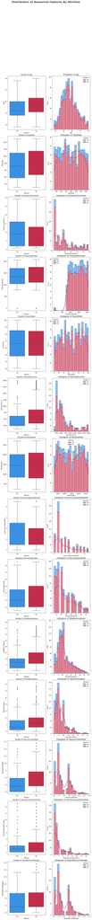

```python
clr1 = ['#1E90FF', '#DC143C']
fig, ax = plt.subplots(14, 2, figsize=(10,100))
fig.suptitle('Distribution of Numerical Features By Attrition', color='#3C3744',
             fontsize=20, fontweight='bold', ha='center')
for i, col in enumerate(continues_features):
    sns.boxplot(data=df, x='Attrition', y=col,  palette=clr1, ax=ax[i,0])
    ax[i,0].set_title(f'Boxplot of {col}', fontsize=12)
    sns.histplot(data=df, x=col, hue='Attrition', bins=20, kde=True,
                 multiple='stack', palette=clr1, ax=ax[i,1])
    ax[i,1].set_title(f'Histogram of {col}', fontsize=14)
fig.tight_layout()
fig.subplots_adjust(top=0.90)
```

```python
# Target variable visualization
```

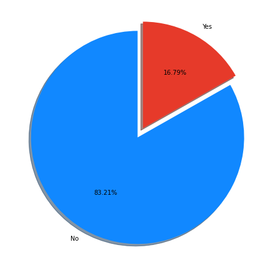

```python
percentage = df.Attrition.value_counts(normalize=True)*100
labels = ["No","Yes"]

# Plot PieChart with Ploty library
fig, ax = plt.subplots(figsize =(15, 8))
explode = (0, 0.1)
colors = ['#1188ff','#e63a2a']
ax.pie(percentage, labels = labels, startangle = 90,
       autopct='%1.2f%%',explode=explode, shadow=True, colors=colors)
plt.show()
```

- From the chart it is seen that the Target Variable is Imbalanced

```python
df.columns
```

```
Index(['Age', 'Attrition', 'BusinessTravel', 'DailyRate', 'Department',
       'DistanceFromHome', 'Education', 'EducationField', 'EmployeeCount',
       'EmployeeNumber', 'EnvironmentSatisfaction', 'Gender', 'HourlyRate',
       'JobInvolvement', 'JobLevel', 'JobRole', 'JobSatisfaction',
       'MaritalStatus', 'MonthlyIncome', 'MonthlyRate', 'NumCompaniesWorked',
       'Over18', 'OverTime', 'PercentSalaryHike', 'PerformanceRating',
       'RelationshipSatisfaction', 'StandardHours', 'StockOptionLevel',
       'TotalWorkingYears', 'TrainingTimesLastYear', 'WorkLifeBalance',
       'YearsAtCompany', 'YearsInCurrentRole', 'YearsSinceLastPromotion',
       'YearsWithCurrManager'],
      dtype='object')
```

```python
#group data by Age and their count of Attrition
df.groupby('Age')['Attrition'].value_counts(normalize=True).to_frame()*100
```

| Age | Attrition | Attrition |
| --- | --- | --- |
| 18 | No | 60.0 |
|  | Yes | 40.0 |
| 19 | No | 50.0 |
|  | Yes | 50.0 |
| 20 | No | 50.0 |
| ... | ... | ... |
| 57 | No | 100.0 |
| 58 | No | 60.0 |
|  | Yes | 40.0 |
| 59 | No | 100.0 |
| 60 | No | 100.0 |

82 rows × 1 columns

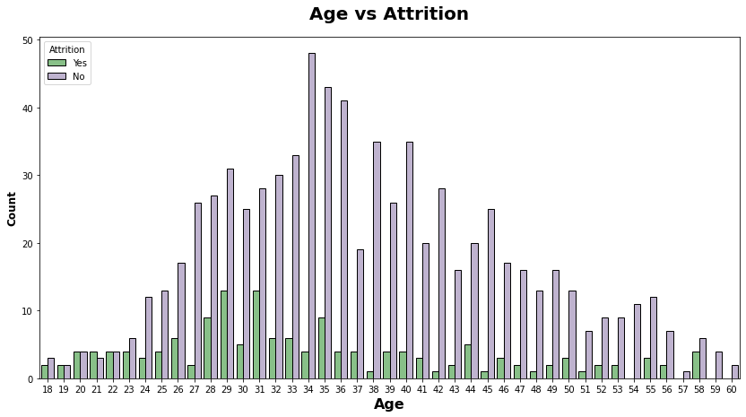

```python
plt.subplots(figsize=(14,7))
sns.countplot(x="Age",hue="Attrition", data=df, ec = "black",palette="Accent")
plt.title("Age vs Attrition", weight="bold",fontsize=20, pad=20)
plt.ylabel("Count", weight="bold", fontsize=12)
plt.xlabel("Age", weight="bold", fontsize=16)
plt.legend(title="Attrition", fancybox=True)
plt.show()
```

```python
df2 = df.copy()
```

[output not shown]

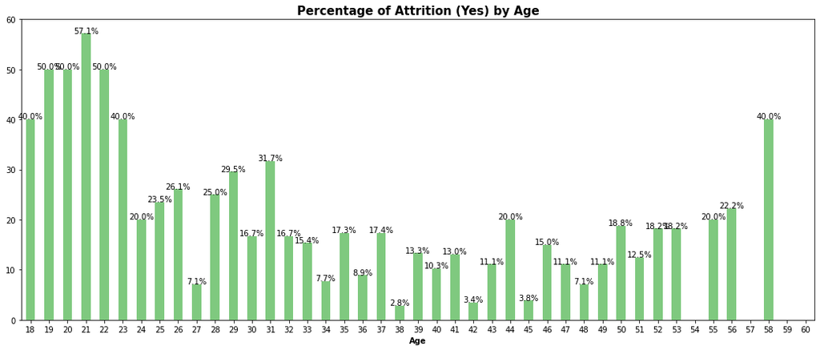

```python
plt.figure(figsize=[18,7])

(df2[df2["Attrition"] == 'Yes']['Age'].value_counts() * 100 / df2['Age'].value_counts()).plot(
    kind='bar', stacked=True, colormap='Accent')
plt.title("Percentage of Attrition (Yes) by Age", fontsize=15, fontweight='bold')
order1 = (100 * df2[df2["Attrition"] == 'Yes']['Age'].value_counts() / df2['Age'].value_counts())
for n in range(order1.shape[0]):
    count = order1.iloc[n]
    strt = '{:0.1f}%'.format(count)
    plt.text(n, count + 0.1, strt, ha='center')

plt.xlabel('Age', fontweight='bold')
plt.xticks(rotation=0)
plt.show()
```

As per visualization age group 18 to 23 have highest rate of Attrition

```python
categorical_features
```

```
['Attrition',
 'BusinessTravel',
 'Department',
 'EducationField',
 'Gender',
 'JobRole',
 'MaritalStatus',
 'OverTime']
```

```python
#group data by BusinessTravel and their count of Attrition
df.groupby('BusinessTravel')['Attrition'].value_counts(normalize=True).to_frame()*100
```

| BusinessTravel | Attrition | Attrition |
| --- | --- | --- |
| Non-Travel | No | 90.721649 |
|  | Yes | 9.278351 |
| Travel_Frequently | No | 74.418605 |
|  | Yes | 25.581395 |
| Travel_Rarely | No | 84.413580 |
|  | Yes | 15.586420 |

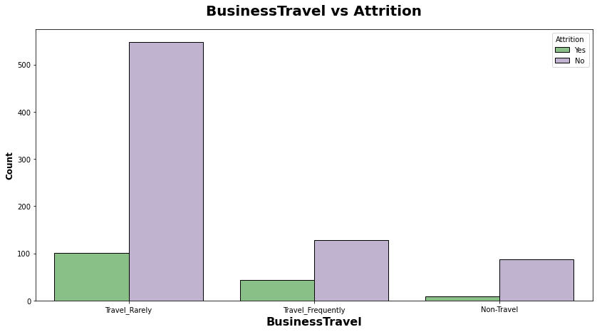

```python
plt.subplots(figsize=(14,7))
sns.countplot(x="BusinessTravel",hue="Attrition", data=df, ec = "black",palette="Accent")
plt.title("BusinessTravel vs Attrition", weight="bold",fontsize=20, pad=20)
plt.ylabel("Count", weight="bold", fontsize=12)
plt.xlabel("BusinessTravel", weight="bold", fontsize=16)
plt.legend(title="Attrition", fancybox=True)
plt.show()
```

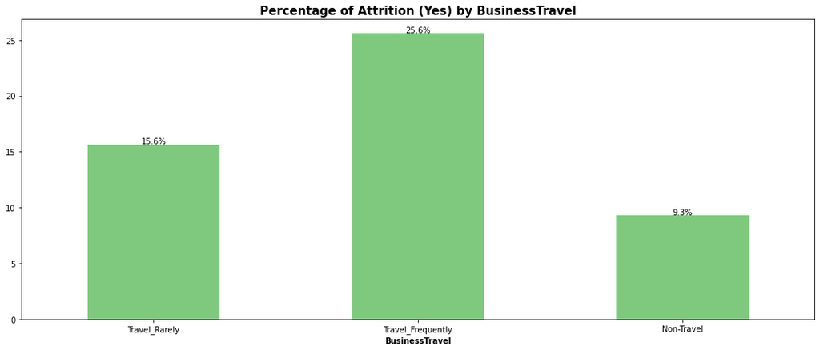

```python
plt.figure(figsize=[18,7])

(df2[df2["Attrition"] == 'Yes']['BusinessTravel'].value_counts() * 100 / df2['BusinessTravel'].value_counts()).plot(
    kind='bar', stacked=True, colormap='Accent')
plt.title("Percentage of Attrition (Yes) by BusinessTravel", fontsize=15, fontweight='bold')
order1 = (100 * df2[df2["Attrition"] == 'Yes']['BusinessTravel'].value_counts() / df2['BusinessTravel'].value_counts())
for n in range(order1.shape[0]):
    count = order1.iloc[n]
    strt = '{:0.1f}%'.format(count)
    plt.text(n, count + 0.1, strt, ha='center')

plt.xlabel('BusinessTravel', fontweight='bold')
plt.xticks(rotation=0)
plt.show()
```

Attrition rate is high in Travel_frequently

```python
#group data by BusinessTravel and their count of Attrition
df.groupby('Department')['Attrition'].value_counts(normalize=True).to_frame()*100
```

| Department | Attrition | Attrition |
| --- | --- | --- |
| Human Resources | No | 82.222222 |
|  | Yes | 17.777778 |
| Research & Development | No | 85.762144 |
|  | Yes | 14.237856 |
| Sales | No | 77.818182 |
|  | Yes | 22.181818 |

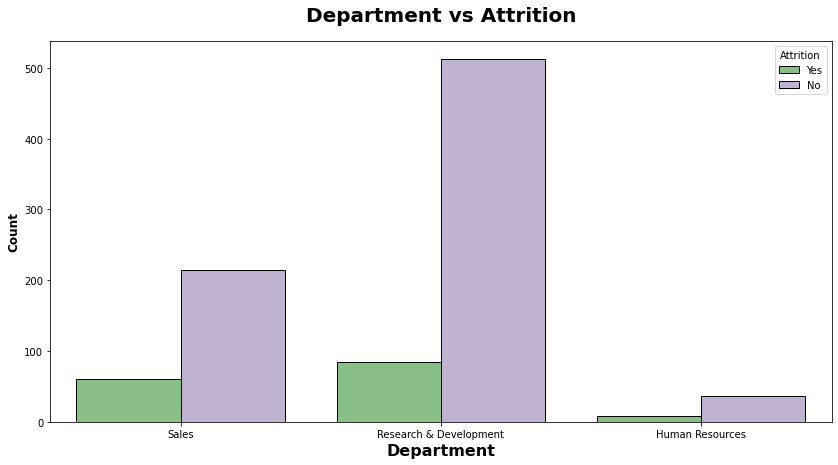

```python
plt.subplots(figsize=(14,7))
sns.countplot(x="Department",hue="Attrition", data=df, ec = "black",palette="Accent")
plt.title("Department vs Attrition", weight="bold",fontsize=20, pad=20)
plt.ylabel("Count", weight="bold", fontsize=12)
plt.xlabel("Department", weight="bold", fontsize=16)
plt.legend(title="Attrition", fancybox=True)
plt.show()
```

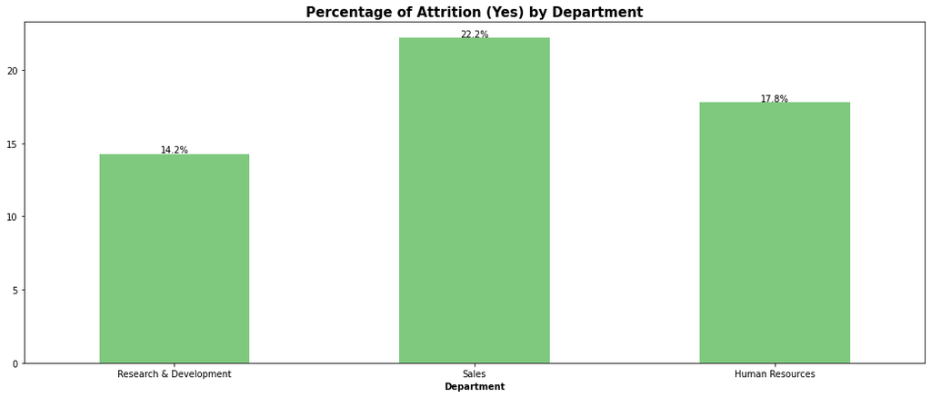

```python
plt.figure(figsize=[18,7])

(df2[df2["Attrition"] == 'Yes']['Department'].value_counts() * 100 / df2['Department'].value_counts()).plot(
    kind='bar', stacked=True, colormap='Accent')
plt.title("Percentage of Attrition (Yes) by Department", fontsize=15, fontweight='bold')
order1 = (100 * df2[df2["Attrition"] == 'Yes']['Department'].value_counts() / df2['Department'].value_counts())
for n in range(order1.shape[0]):
    count = order1.iloc[n]
    strt = '{:0.1f}%'.format(count)
    plt.text(n, count + 0.1, strt, ha='center')

plt.xlabel('Department', fontweight='bold')
plt.xticks(rotation=0)
plt.show()
```

Attrition rate is high in sales department

```python
#group data by BusinessTravel and their count of Attrition
df.groupby('EducationField')['Attrition'].value_counts(normalize=True).to_frame()*100
```

| EducationField | Attrition | Attrition |
| --- | --- | --- |
| Human Resources | No | 72.222222 |
|  | Yes | 27.777778 |
| Life Sciences | No | 84.155844 |
|  | Yes | 15.844156 |
| Marketing | No | 77.173913 |
|  | Yes | 22.826087 |
| Medical | No | 85.614035 |
|  | Yes | 14.385965 |
| Other | No | 83.636364 |
|  | Yes | 16.363636 |
| Technical Degree | No | 79.268293 |
|  | Yes | 20.731707 |

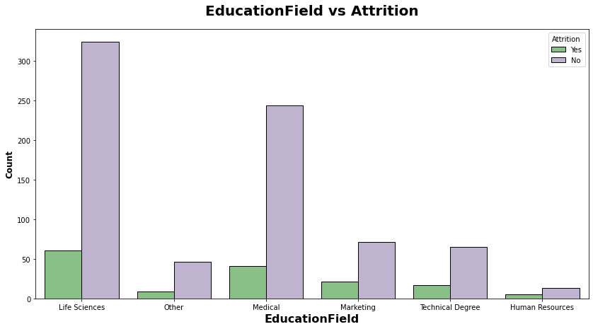

```python
plt.subplots(figsize=(14,7))
sns.countplot(x="EducationField",hue="Attrition", data=df, ec = "black",palette="Accent")
plt.title("EducationField vs Attrition", weight="bold",fontsize=20, pad=20)
plt.ylabel("Count", weight="bold", fontsize=12)
plt.xlabel("EducationField", weight="bold", fontsize=16)
plt.legend(title="Attrition", fancybox=True)
plt.show()
```

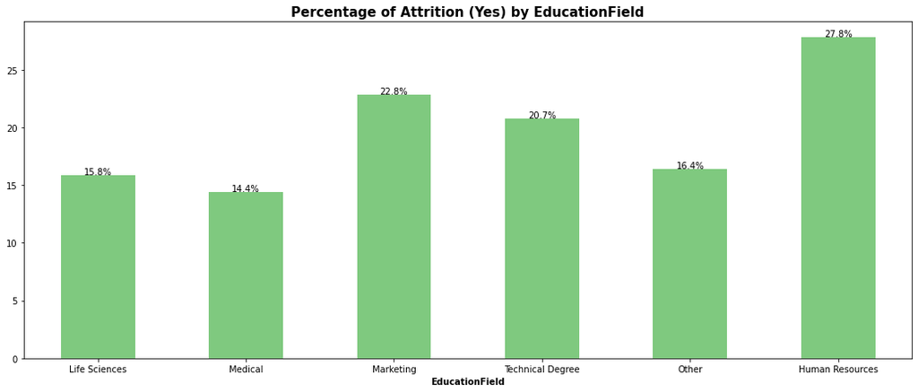

```python
plt.figure(figsize=[18,7])

(df2[df2["Attrition"] == 'Yes']['EducationField'].value_counts() * 100 / df2['EducationField'].value_counts()).plot(
    kind='bar', stacked=True, colormap='Accent')
plt.title("Percentage of Attrition (Yes) by EducationField", fontsize=15, fontweight='bold')
order1 = (100 * df2[df2["Attrition"] == 'Yes']['EducationField'].value_counts() / df2['EducationField'].value_counts())
for n in range(order1.shape[0]):
    count = order1.iloc[n]
    strt = '{:0.1f}%'.format(count)
    plt.text(n, count + 0.1, strt, ha='center')

plt.xlabel('EducationField', fontweight='bold')
plt.xticks(rotation=0)
plt.show()
```

```python
#group data by Gender and their count of Attrition
df.groupby('Gender')['Attrition'].value_counts(normalize=True).to_frame()*100
```

| Gender | Attrition | Attrition |
| --- | --- | --- |
| Female | No | 83.378747 |
|  | Yes | 16.621253 |
| Male | No | 83.090909 |
|  | Yes | 16.909091 |

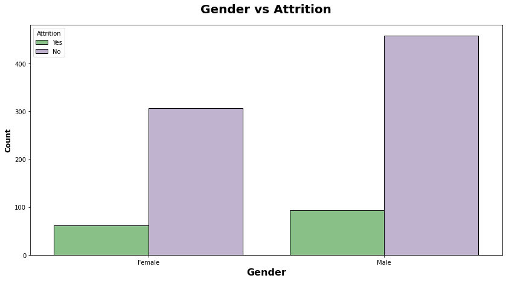

```python
plt.subplots(figsize=(14,7))
sns.countplot(x="Gender",hue="Attrition", data=df, ec = "black",palette="Accent")
plt.title("Gender vs Attrition", weight="bold",fontsize=20, pad=20)
plt.ylabel("Count", weight="bold", fontsize=12)
plt.xlabel("Gender", weight="bold", fontsize=16)
plt.legend(title="Attrition", fancybox=True)
plt.show()
```

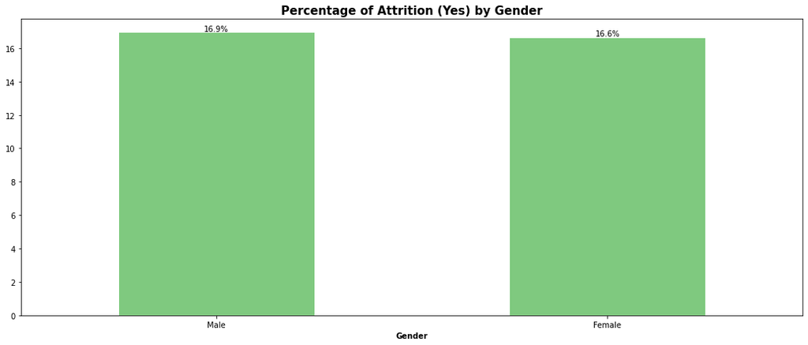

```python
plt.figure(figsize=[18,7])

(df2[df2["Attrition"] == 'Yes']['Gender'].value_counts() * 100 / df2['Gender'].value_counts()).plot(
    kind='bar', stacked=True, colormap='Accent')
plt.title("Percentage of Attrition (Yes) by Gender", fontsize=15, fontweight='bold')
order1 = (100 * df2[df2["Attrition"] == 'Yes']['Gender'].value_counts() / df2['Gender'].value_counts())
for n in range(order1.shape[0]):
    count = order1.iloc[n]
    strt = '{:0.1f}%'.format(count)
    plt.text(n, count + 0.1, strt, ha='center')

plt.xlabel('Gender', fontweight='bold')
plt.xticks(rotation=0)
plt.show()
```

Gender and Education_filed doesnt make have more impact on attiration

```python
#group data by JobRole and their count of Attrition
df.groupby('JobRole')['Attrition'].value_counts(normalize=True).to_frame()*100
```

| JobRole | Attrition | Attrition |
| --- | --- | --- |
| Healthcare Representative | No | 92.771084 |
|  | Yes | 7.228916 |
| Human Resources | No | 79.487179 |
|  | Yes | 20.512821 |
| Laboratory Technician | No | 75.308642 |
|  | Yes | 24.691358 |
| Manager | No | 94.827586 |
|  | Yes | 5.172414 |
| Manufacturing Director | No | 92.391304 |
|  | Yes | 7.608696 |
| Research Director | No | 97.916667 |
|  | Yes | 2.083333 |
| Research Scientist | No | 83.516484 |
|  | Yes | 16.483516 |
| Sales Executive | No | 80.295567 |
|  | Yes | 19.704433 |
| Sales Representative | No | 62.000000 |
|  | Yes | 38.000000 |

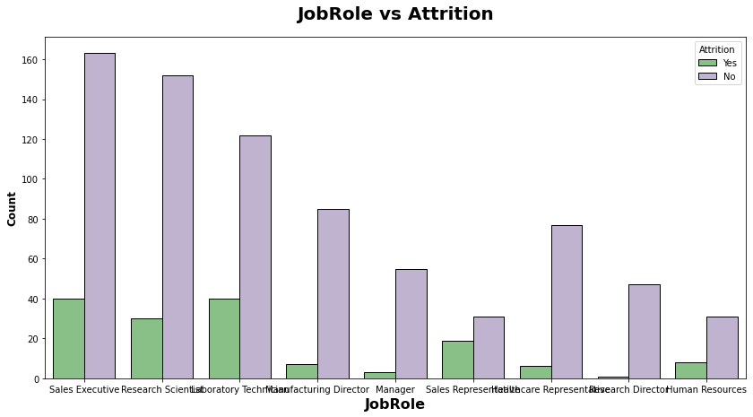

```python
plt.subplots(figsize=(14,7))
sns.countplot(x="JobRole",hue="Attrition", data=df, ec = "black",palette="Accent")
plt.title("JobRole vs Attrition", weight="bold",fontsize=20, pad=20)
plt.ylabel("Count", weight="bold", fontsize=12)
plt.xlabel("JobRole", weight="bold", fontsize=16)
plt.legend(title="Attrition", fancybox=True)
plt.show()
```

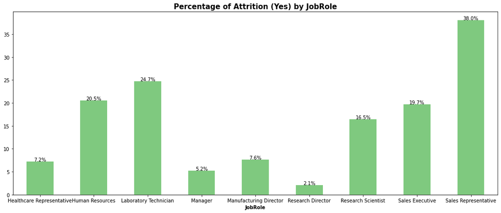

```python
plt.figure(figsize=[18,7])

(df2[df2["Attrition"] == 'Yes']['JobRole'].value_counts() * 100 / df2['JobRole'].value_counts()).plot(
    kind='bar', stacked=True, colormap='Accent')
plt.title("Percentage of Attrition (Yes) by JobRole", fontsize=15, fontweight='bold')
order1 = (100 * df2[df2["Attrition"] == 'Yes']['JobRole'].value_counts() / df2['JobRole'].value_counts())
for n in range(order1.shape[0]):
    count = order1.iloc[n]
    strt = '{:0.1f}%'.format(count)
    plt.text(n, count + 0.1, strt, ha='center')

plt.xlabel('JobRole', fontweight='bold')
plt.xticks(rotation=0)
plt.show()
```

Column sales_representative has more attrition

```python
#group data by MaritalStatus and their count of Attrition
df.groupby('MaritalStatus')['Attrition'].value_counts(normalize=True).to_frame()*100
```

| MaritalStatus | Attrition | Attrition |
| --- | --- | --- |
| Divorced | No | 88.659794 |
|  | Yes | 11.340206 |
| Married | No | 87.614679 |
|  | Yes | 12.385321 |
| Single | No | 72.822300 |
|  | Yes | 27.177700 |

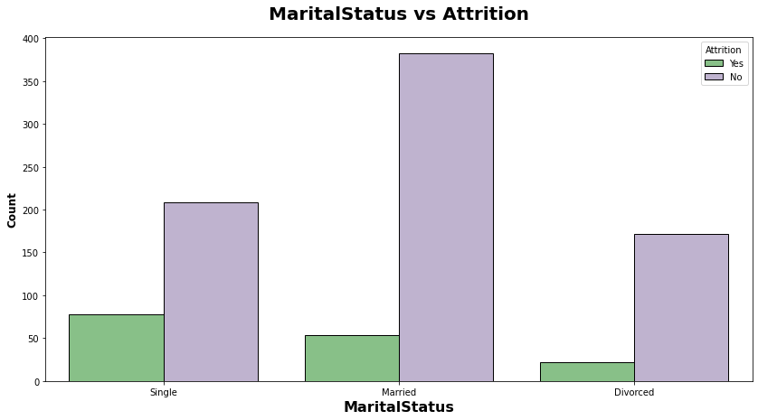

```python
plt.subplots(figsize=(14,7))
sns.countplot(x="MaritalStatus",hue="Attrition", data=df, ec = "black",palette="Accent")
plt.title("MaritalStatus vs Attrition", weight="bold",fontsize=20, pad=20)
plt.ylabel("Count", weight="bold", fontsize=12)
plt.xlabel("MaritalStatus", weight="bold", fontsize=16)
plt.legend(title="Attrition", fancybox=True)
plt.show()
```

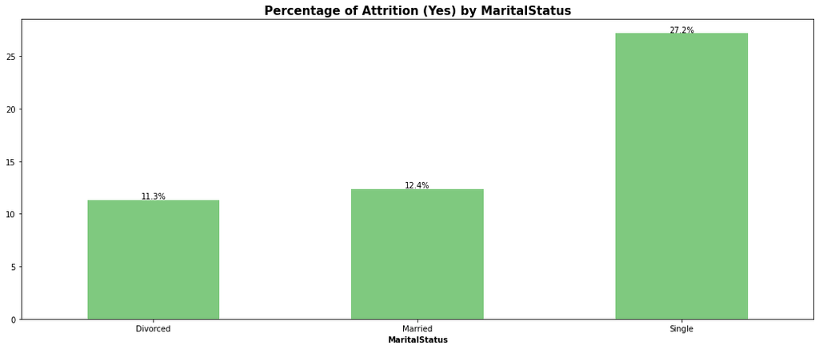

```python
plt.figure(figsize=[18,7])

(df2[df2["Attrition"] == 'Yes']['MaritalStatus'].value_counts() * 100 / df2['MaritalStatus'].value_counts()).plot(
    kind='bar', stacked=True, colormap='Accent')
plt.title("Percentage of Attrition (Yes) by MaritalStatus", fontsize=15, fontweight='bold')
order1 = (100 * df2[df2["Attrition"] == 'Yes']['MaritalStatus'].value_counts() / df2['MaritalStatus'].value_counts())
for n in range(order1.shape[0]):
    count = order1.iloc[n]
    strt = '{:0.1f}%'.format(count)
    plt.text(n, count + 0.1, strt, ha='center')

plt.xlabel('MaritalStatus', fontweight='bold')
plt.xticks(rotation=0)
plt.show()
```

```python
#group data by OverTime and their count of Attrition
df.groupby('OverTime')['Attrition'].value_counts(normalize=True).to_frame()*100
```

| OverTime | Attrition | Attrition |
| --- | --- | --- |
| No | No | 88.871951 |
|  | Yes | 11.128049 |
| Yes | No | 68.965517 |
|  | Yes | 31.034483 |

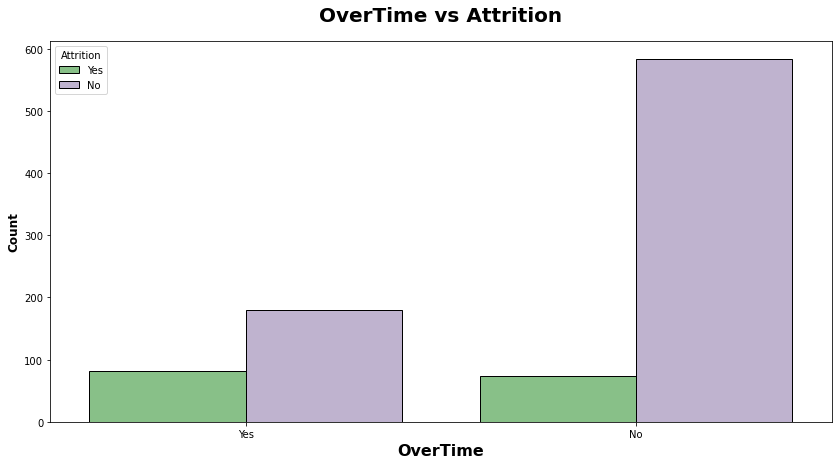

```python
plt.subplots(figsize=(14,7))
sns.countplot(x="OverTime",hue="Attrition", data=df, ec = "black",palette="Accent")
plt.title("OverTime vs Attrition", weight="bold",fontsize=20, pad=20)
plt.ylabel("Count", weight="bold", fontsize=12)
plt.xlabel("OverTime", weight="bold", fontsize=16)
plt.legend(title="Attrition", fancybox=True)
plt.show()
```

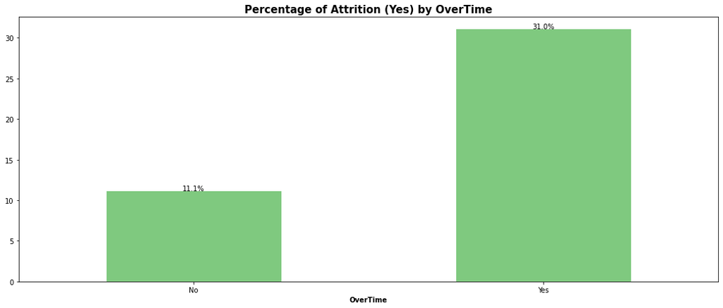

```python
plt.figure(figsize=[18,7])

(df2[df2["Attrition"] == 'Yes']['OverTime'].value_counts() * 100 / df2['OverTime'].value_counts()).plot(
    kind='bar', stacked=True, colormap='Accent')
plt.title("Percentage of Attrition (Yes) by OverTime", fontsize=15, fontweight='bold')
order1 = (100 * df2[df2["Attrition"] == 'Yes']['OverTime'].value_counts() / df2['OverTime'].value_counts())
for n in range(order1.shape[0]):
    count = order1.iloc[n]
    strt = '{:0.1f}%'.format(count)
    plt.text(n, count + 0.1, strt, ha='center')

plt.xlabel('OverTime', fontweight='bold')
plt.xticks(rotation=0)
plt.show()
```

OverTime employee has more attrition level

```python
##these are the features with nan value
features_with_na=[features for features in df.columns if df[features].isnull().sum()>=1]
for feature in features_with_na:
    print(feature,np.round(df[feature].isnull().mean()*100,5), '% missing values')
```

```python
features_with_na
```

```
[]
```

```python
df.duplicated().sum()
```

```
0
```

```python
df.head()
```

|  | Age | Attrition | BusinessTravel | DailyRate | Department | DistanceFromHome | Education | EducationField | EmployeeCount | EmployeeNumber | EnvironmentSatisfaction | Gender | HourlyRate | JobInvolvement | JobLevel | JobRole | JobSatisfaction | MaritalStatus | MonthlyIncome | MonthlyRate | NumCompaniesWorked | Over18 | OverTime | PercentSalaryHike | PerformanceRating | RelationshipSatisfaction | StandardHours | StockOptionLevel | TotalWorkingYears | … |
| --- | --- | --- | --- | --- | --- | --- | --- | --- | --- | --- | --- | --- | --- | --- | --- | --- | --- | --- | --- | --- | --- | --- | --- | --- | --- | --- | --- | --- | --- | --- |
| 0 | 41 | Yes | Travel_Rarely | 1102 | Sales | 1 | 2 | Life Sciences | 1 | 1 | 2 | Female | 94 | 3 | 2 | Sales Executive | 4 | Single | 5993 | 19479 | 8 | Y | Yes | 11 | 3 | 1 | 80 | 0 | 8 | … |
| 1 | 49 | No | Travel_Frequently | 279 | Research & Development | 8 | 1 | Life Sciences | 1 | 2 | 3 | Male | 61 | 2 | 2 | Research Scientist | 2 | Married | 5130 | 24907 | 1 | Y | No | 23 | 4 | 4 | 80 | 1 | 10 | … |
| 2 | 37 | Yes | Travel_Rarely | 1373 | Research & Development | 2 | 2 | Other | 1 | 4 | 4 | Male | 92 | 2 | 1 | Laboratory Technician | 3 | Single | 2090 | 2396 | 6 | Y | Yes | 15 | 3 | 2 | 80 | 0 | 7 | … |
| 3 | 33 | No | Travel_Frequently | 1392 | Research & Development | 3 | 4 | Life Sciences | 1 | 5 | 4 | Female | 56 | 3 | 1 | Research Scientist | 3 | Married | 2909 | 23159 | 1 | Y | Yes | 11 | 3 | 3 | 80 | 0 | 8 | … |
| 4 | 27 | No | Travel_Rarely | 591 | Research & Development | 2 | 1 | Medical | 1 | 7 | 1 | Male | 40 | 3 | 1 | Laboratory Technician | 2 | Married | 3468 | 16632 | 9 | Y | No | 12 | 3 | 4 | 80 | 1 | 6 | … |

```python
num_features = [feature for feature in df.columns if df[feature].dtype != 'O']
print('Num of Numerical Features :', len(num_features))
```

```
Num of Numerical Features : 26
```

```python
cat_features = [feature for feature in df.columns if df[feature].dtype == 'O']
print('Num of Categorical Features :', len(cat_features))
```

```
Num of Categorical Features : 9
```

```python
discrete_features=[feature for feature in num_features if len(df[feature].unique())<=25]
print('Num of Discrete Features :',len(discrete_features))
```

```
Num of Discrete Features : 17
```

```python
continuous_features=[feature for feature in num_features if feature not in discrete_features]
print('Num of Continuous Features :',len(continuous_features))
```

```
Num of Continuous Features : 9
```

```python
X = df.drop('Attrition', axis=1)
y = df['Attrition']
```

```python
y.head()
```

```
0    Yes
1     No
2    Yes
3     No
4     No
Name: Attrition, dtype: object
```

```python
# If the target column has Denied it is encoded as 1 others as 0
y= np.where(y=='No', 1,0)
```

```python
y
```

```
array([0, 1, 0, 1, 1, 1, 1, 1, 1, 0, 1, 1, 1, 0, 1, 0, 1, 1, 1, 1, 0, 1,
       1, 1, 1, 1, 1, 1, 1, 1, 1, 1, 0, 1, 1, 1, 0, 1, 0, 1, 1, 1, 0, 1,
       1, 0, 1, 1, 1, 1, 1, 1, 1, 1, 0, 0, 1, 1, 1, 1, 1, 0, 1, 1, 1, 1,
       1, 1, 1, 1, 1, 1, 1, 1, 1, 1, 1, 1, 1, 1, 1, 1, 1, 0, 1, 1, 1, 1,
       1, 1, 1, 1, 0, 1, 1, 1, 1, 1, 1, 1, 1, 1, 1, 0, 1, 1, 1, 0, 1, 0,
       0, 1, 1, 0, 0, 1, 0, 1, 1, 1, 1, 1, 1, 1, 1, 1, 1, 1, 1, 1, 0, 1,
       1, 1, 1, 0, 0, 1, 1, 1, 0, 1, 0, 1, 1, 1, 1, 0, 1, 1, 1, 1, 1, 0,
       1, 1, 0, 1, 0, 1, 1, 1, 1, 1, 1, 1, 1, 0, 1, 1, 1, 1, 0, 1, 1, 1,
       1, 1, 0, 0, 1, 1, 1, 1, 1, 1, 1, 1, 1, 1, 1, 0, 1, 1, 1, 0, 0, 1,
       1, 0, 1, 1, 1, 1, 1, 1, 1, 1, 0, 0, 1, 1, 1, 1, 1, 1, 1, 1, 1, 1,
       1, 1, 1, 0, 0, 1, 0, 0, 1, 1, 1, 1, 1, 1, 1, 1, 0, 1, 0, 0, 1, 1,
       1, 0, 0, 0, 1, 0, 0, 1, 1, 1, 1, 1, 1, 1, 1, 1, 1, 1, 0, 1, 1, 1,
       1, 1, 1, 1, 1, 1, 1, 1, 1, 1, 1, 0, 0, 1, 0, 1, 1, 1, 1, 0, 1, 0,
       1, 1, 1, 0, 1, 1, 1, 1, 1, 1, 0, 1, 1, 1, 1, 1, 1, 1, 0, 1, 1, 0,
       1, 1, 1, 0, 1, 1, 1, 1, 1, 1, 0, 1, 1, 1, 1, 1, 1, 1, 1, 1, 1, 1,
```

[output cut: 27 more lines]

```python
continuous_features
```

```
['Age',
 'DailyRate',
 'DistanceFromHome',
 'EmployeeNumber',
 'HourlyRate',
 'MonthlyIncome',
 'MonthlyRate',
 'TotalWorkingYears',
 'YearsAtCompany']
```

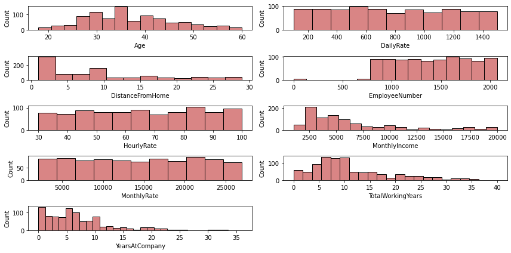

```python
# distribution of data before scaling
plt.figure(figsize=(12, 6))
for i, col in enumerate(['Age',
 'DailyRate',
 'DistanceFromHome',
 'EmployeeNumber',
 'HourlyRate',
 'MonthlyIncome',
 'MonthlyRate',
 'TotalWorkingYears',
 'YearsAtCompany']):
    plt.subplot(5, 2, i+1)
    sns.histplot(x=X[col], color='indianred')
    plt.xlabel(col)
    plt.tight_layout()
```

```python
# Check Skewness
X[continuous_features].skew(axis=0, skipna=True)
```

```
Age                  0.392743
DailyRate            0.044223
DistanceFromHome     0.926858
EmployeeNumber      -0.216251
HourlyRate          -0.057398
MonthlyIncome        1.398515
MonthlyRate          0.007792
TotalWorkingYears    1.138436
YearsAtCompany       1.682701
dtype: float64
```

```python
## Outlier Treatment
```

```python
from sklearn.preprocessing import PowerTransformer
pt = PowerTransformer(method='yeo-johnson')
transform_features = ['MonthlyIncome', 'TotalWorkingYears','YearsAtCompany']
X_copy = pt.fit_transform(X[transform_features])
```

```python
X_copy = pd.DataFrame(X_copy, columns=transform_features)
```

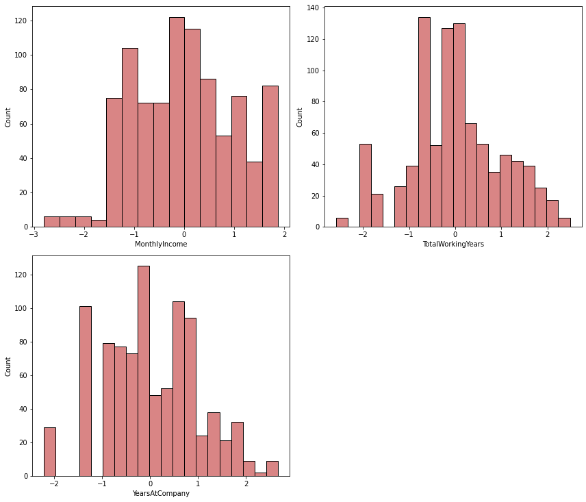

```python
plt.figure(figsize=(12, 25))
for i, col in enumerate(transform_features):
    plt.subplot(5, 2, i+1)
    sns.histplot(x=X_copy[col], color='indianred')
    plt.xlabel(col)
    plt.tight_layout()
```

```python
X_copy.skew(axis=0, skipna=True)
```

```
MonthlyIncome        0.030809
TotalWorkingYears   -0.009901
YearsAtCompany      -0.010497
dtype: float64
```

```python
for feature in cat_features:
    print(feature,':', df[feature].nunique())
```

```
Attrition : 2
BusinessTravel : 3
Department : 3
EducationField : 6
Gender : 2
JobRole : 9
MaritalStatus : 3
Over18 : 1
OverTime : 2
```

```python
num_features = list(X.select_dtypes(exclude="object").columns)
```

```python
num_features
```

```
['Age',
 'DailyRate',
 'DistanceFromHome',
 'Education',
 'EmployeeCount',
 'EmployeeNumber',
 'EnvironmentSatisfaction',
 'HourlyRate',
 'JobInvolvement',
 'JobLevel',
 'JobSatisfaction',
 'MonthlyIncome',
 'MonthlyRate',
 'NumCompaniesWorked',
 'PercentSalaryHike',
 'PerformanceRating',
 'RelationshipSatisfaction',
 'StandardHours',
 'StockOptionLevel',
 'TotalWorkingYears',
 'TrainingTimesLastYear',
 'WorkLifeBalance',
 'YearsAtCompany',
 'YearsInCurrentRole',
 'YearsSinceLastPromotion',
 'YearsWithCurrManager']
```

```python
# Create Column Transformer with 3 types of transformers
or_columns = ['Gender','OverTime','Over18']
oh_columns = ['BusinessTravel','Department','EducationField','JobRole','MaritalStatus']
transform_columns= ['Age','DailyRate','DistanceFromHome','Education','EmployeeCount','EmployeeNumber','EnvironmentSatisfaction','HourlyRate','JobInvolvement','JobLevel','JobSatisfaction','MonthlyIncome','MonthlyRate','NumCompaniesWorked','PercentSalaryHike','PerformanceRating','RelationshipSatisfaction','StandardHours','StockOptionLevel','TotalWorkingYears','TrainingTimesLastYear','WorkLifeBalance','YearsAtCompany','YearsInCurrentRole','YearsSinceLastPromotion','YearsWithCurrManager']

from sklearn.preprocessing import OneHotEncoder, StandardScaler,OrdinalEncoder, PowerTransformer
from sklearn.compose import ColumnTransformer
from sklearn.pipeline import Pipeline

numeric_transformer = StandardScaler()
oh_transformer = OneHotEncoder()
ordinal_encoder = OrdinalEncoder()

transform_pipe = Pipeline(steps=[
    ('transformer', PowerTransformer(method='yeo-johnson'))
])

preprocessor = ColumnTransformer(
    [
        ("OneHotEncoder", oh_transformer, oh_columns),
        ("Ordinal_Encoder", ordinal_encoder, or_columns),
        ("Transformer", transform_pipe, transform_columns),
        ("StandardScaler", numeric_transformer, num_features)
    ]
)
```

```python
X = preprocessor.fit_transform(X)
```

```python
X
```

```
array([[ 0.        ,  0.        ,  1.        , ..., -0.06051197,
        -0.67639224,  0.26274115],
       [ 0.        ,  1.        ,  0.        , ...,  0.77601274,
        -0.36138377,  0.82305194],
       [ 0.        ,  0.        ,  1.        , ..., -1.17587825,
        -0.67639224, -1.13803581],
       ...,
       [ 0.        ,  0.        ,  1.        , ..., -0.61819511,
        -0.67639224, -0.29756963],
       [ 0.        ,  1.        ,  0.        , ...,  0.49717117,
        -0.67639224,  1.10320733],
       [ 0.        ,  0.        ,  1.        , ..., -0.33935354,
        -0.36138377, -0.57772503]])
```

```python
from imblearn.combine import SMOTETomek, SMOTEENN
smt = SMOTEENN(random_state=42,sampling_strategy='minority' )
X_res, y_res = smt.fit_resample(X, y)
```

```python
from sklearn.model_selection import  train_test_split
# separate dataset into train and test
X_train, X_test, y_train, y_test = train_test_split(X_res,y_res,test_size=0.2,random_state=42)
X_train.shape, X_test.shape
```

```
((830, 79), (208, 79))
```

```python
from sklearn.ensemble import RandomForestClassifier, AdaBoostClassifier, GradientBoostingClassifier
from sklearn.linear_model import LogisticRegression
from sklearn.neighbors import KNeighborsClassifier
from sklearn.tree import DecisionTreeClassifier
from sklearn.svm import SVC
from sklearn.metrics import accuracy_score, classification_report,ConfusionMatrixDisplay, \
                            precision_score, recall_score, f1_score, roc_auc_score,roc_curve
from xgboost import XGBClassifier
from catboost import CatBoostClassifier
```

```python
def evaluate_clf(true, predicted):
    acc = accuracy_score(true, predicted) # Calculate Accuracy
    f1 = f1_score(true, predicted) # Calculate F1-score
    precision = precision_score(true, predicted) # Calculate Precision
    recall = recall_score(true, predicted)  # Calculate Recall
    roc_auc = roc_auc_score(true, predicted) #Calculate Roc
    return acc, f1 , precision, recall, roc_auc
```

```python
models = {
    "Random Forest": RandomForestClassifier(),
    "Decision Tree": DecisionTreeClassifier(),
    "Gradient Boosting": GradientBoostingClassifier(),
    "Logistic Regression": LogisticRegression(),
     "K-Neighbors Classifier": KNeighborsClassifier(),
    "XGBClassifier": XGBClassifier(),
     "CatBoosting Classifier": CatBoostClassifier(verbose=False),
     "Support Vector Classifier": SVC(),
    "AdaBoost Classifier": AdaBoostClassifier()
}
```

```python
# Create a function which can evaluate models and return a report
def evaluate_models(X, y, models):
    '''
    This function takes in X and y and models dictionary as input
    It splits the data into Train Test split
    Iterates through the given model dictionary and evaluates the metrics
    Returns: Dataframe which contains report of all models metrics with cost
    '''
    # separate dataset into train and test
    X_train, X_test, y_train, y_test = train_test_split(X,y,test_size=0.2,random_state=42)

    models_list = []
    accuracy_list = []
    auc= []

    for i in range(len(list(models))):
        model = list(models.values())[i]
        model.fit(X_train, y_train) # Train model

        # Make predictions
        y_train_pred = model.predict(X_train)
        y_test_pred = model.predict(X_test)

        # Training set performance
        model_train_accuracy, model_train_f1,model_train_precision,\
        model_train_recall,model_train_rocauc_score=evaluate_clf(y_train ,y_train_pred)


        # Test set performance
        model_test_accuracy,model_test_f1,model_test_precision,\
        model_test_recall,model_test_rocauc_score=evaluate_clf(y_test, y_test_pred)

        print(list(models.keys())[i])
        models_list.append(list(models.keys())[i])

        print('Model performance for Training set')
        print("- Accuracy: {:.4f}".format(model_train_accuracy))
        print('- F1 score: {:.4f}'.format(model_train_f1))
        print('- Precision: {:.4f}'.format(model_train_precision))
        print('- Recall: {:.4f}'.format(model_train_recall))
        print('- Roc Auc Score: {:.4f}'.format(model_train_rocauc_score))

        print('----------------------------------')

        print('Model performance for Test set')
        print('- Accuracy: {:.4f}'.format(model_test_accuracy))
        accuracy_list.append(model_test_accuracy)
        print('- F1 score: {:.4f}'.format(model_test_f1))
        print('- Precision: {:.4f}'.format(model_test_precision))
        print('- Recall: {:.4f}'.format(model_test_recall))
        print('- Roc Auc Score: {:.4f}'.format(model_test_rocauc_score))
        auc.append(model_test_rocauc_score)
        print('='*35)
        print('\n')

    report=pd.DataFrame(list(zip(models_list, accuracy_list)), columns=['Model Name', 'Accuracy']).sort_values(by=['Accuracy'], ascending=False)

    return report
```

```python
base_model_report =evaluate_models(X=X_res, y=y_res, models=models)
```

```
Random Forest
Model performance for Training set
- Accuracy: 1.0000
- F1 score: 1.0000
- Precision: 1.0000
- Recall: 1.0000
- Roc Auc Score: 1.0000
----------------------------------
Model performance for Test set
- Accuracy: 0.9471
- F1 score: 0.9060
- Precision: 0.9138
- Recall: 0.8983
- Roc Auc Score: 0.9324
===================================


Decision Tree
Model performance for Training set
- Accuracy: 1.0000
- F1 score: 1.0000
- Precision: 1.0000
- Recall: 1.0000
- Roc Auc Score: 1.0000
----------------------------------
Model performance for Test set
- Accuracy: 0.8558
- F1 score: 0.7222
- Precision: 0.7959
- Recall: 0.6610
- Roc Auc Score: 0.7970
===================================


Gradient Boosting
Model performance for Training set
- Accuracy: 0.9964
- F1 score: 0.9936
- Precision: 0.9873
- Recall: 1.0000
```

[output cut: 96 more lines]

```
AdaBoost Classifier
Model performance for Training set
- Accuracy: 0.9627
- F1 score: 0.9333
- Precision: 0.9394
- Recall: 0.9274
- Roc Auc Score: 0.9519
----------------------------------
Model performance for Test set
- Accuracy: 0.9038
- F1 score: 0.8305
- Precision: 0.8305
- Recall: 0.8305
- Roc Auc Score: 0.8817
===================================
```

```python
base_model_report
```

|  | Model Name | Accuracy |
| --- | --- | --- |
| 0 | Random Forest | 0.947115 |
| 7 | Support Vector Classifier | 0.947115 |
| 6 | CatBoosting Classifier | 0.937500 |
| 5 | XGBClassifier | 0.932692 |
| 2 | Gradient Boosting | 0.918269 |
| 8 | AdaBoost Classifier | 0.903846 |
| 4 | K-Neighbors Classifier | 0.889423 |
| 3 | Logistic Regression | 0.870192 |
| 1 | Decision Tree | 0.855769 |

```python
# Random Forest Classifier parameters
rf_params = {
    "max_depth": [10, 12, None, 15, 20],
    "max_features": ['sqrt', 'log2', None],
    "n_estimators": [10, 50, 100, 200]
}

# Support Vector Machine parameters
svm_params = {
    'C': [0.1, 1, 10, 100],
    'kernel': ['linear', 'rbf', 'poly'],
    'gamma': ['scale', 'auto']
}

# CatBoost Classifier parameters
catboost_params = {
    'depth': [3, 6, 9],
    'learning_rate': [0.01, 0.05, 0.1],
    'iterations': [100, 200, 500]
}
```